# Taking the train to University?

[figure not shown]

Auckland Transport Train Image

Come with me on a virtual train ride as we explore into some university students’ experiences on riding Auckland Transport trains to go to and from University, in terms of the train’s arrival time, crowdness levels, and their journey satisfaction!

## The train to Britomart is now arriving . . .

Designed Page Divider

## When did the students catch the train and record their observation?

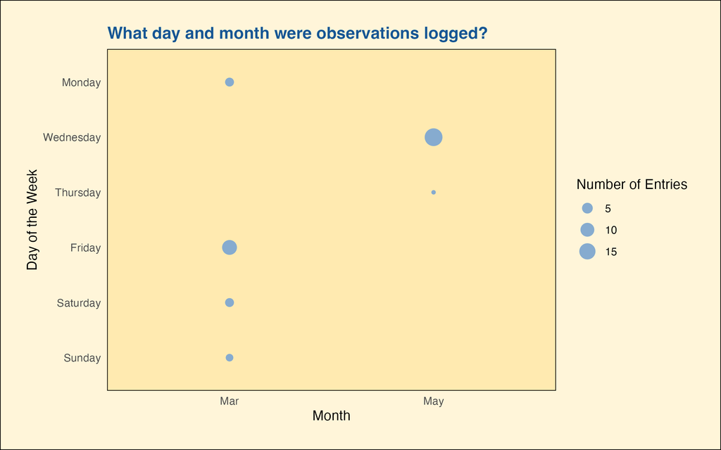

Only some days have entries logged for March as I did not have mobile data to enter live observations onto my Google Form. I instead took note of all my observations on paper and later logged them onto the form whenever I was working on Project 2. For all the entries in May, I have decided to send my Google Form to my friends in order to get at least 20 more observations in time for my Project 4, as I did not take the train as often compared to March. It seems that most of them entered observations on the day I sent the form, glad to know my friends are quick to help!

Now let’s see if these observations can give us any insight on Auckland Transport train patterns…

## We are now arriving at the station . . .

Designed Page Divider

## Will my train arrive late if I take it on a Monday?!

[figure not shown]

This must be frustrating for all university students.. It seems like our train will more likely be late whichever day of the week we go to University.

## We are now arriving at the next station . . .

Designed Page Divider

## Does a busy train affect a student’s experience of listening to their perfectly curated playlist?

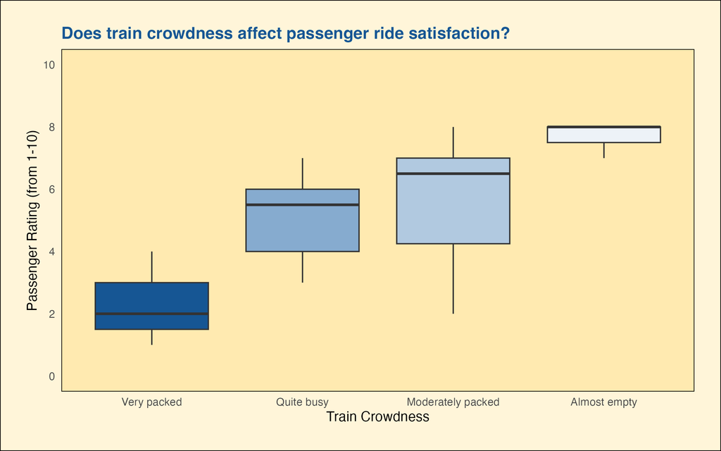

It is evident that the crowdness level of the train does affect how pleasant the passenger finds the train ride. Expecially when the train is almost empty and very packed, with the ride ratings being significantly high (approximately 8/10) and low (approximately 2/10), respectively.

I also would give a low rating if I couldn’t hear my favourite artist singing in my headphones while daydreaming on the train because of how busy it is..

## We are now arriving at the next station . . .

Designed Page Divider

## Does a late train also bring down a student’s mood for the day?

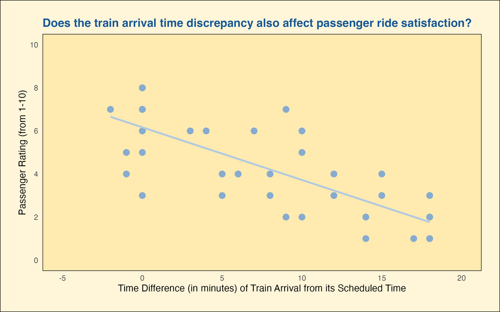

We can also see that train punctuality has a noticeable impact on how passengers rate their ride experience. The linear model above indicates that the later a train arrives, the lower the satisfaction rating tends to be. For students, this could be due to stress of being late to lectures, labs, tests, or simply the frustration of losing time they could’ve spent on studying (or procastination!).

Between you and me, I have had a mental breakdown before on the train when it was 30 minutes delayed. Day ruined.

## We are now arriving at the next station . . .

Designed Page Divider

## Have trains improved, maintained, or become worse with their punctuality in the last 2 months?

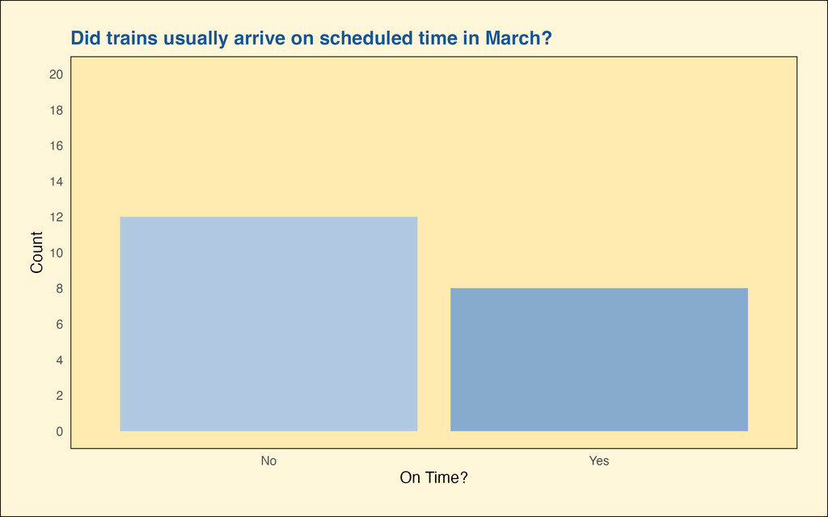

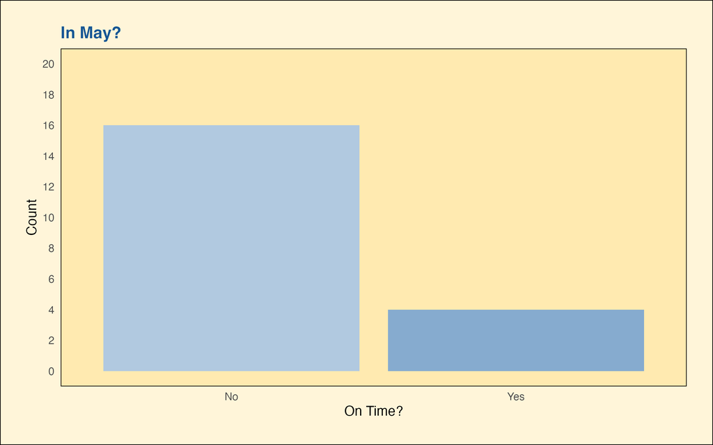

It appears that the punctuality of Auckland Transport trains have worsened over the span of two months. As illustrated in the two graphs above, there were more instances of trains not arriving on time in May compared to March. However, it is important to consider that the entries logged in March were based solely on my own observations of my train rides taken on the Western Line. In contrast, the entries recorded in May were by my friends who take the train on other rail lines such as the Eastern Line and Southern Line. Therefore, the obvious decline in punctuality in May may be also influenced by other rail lines potentially being less punctual than the Western Line.

Will Auckland Transport ever improve with their punctuality??

Designed Page Divider

## We have now arrived at our destination.

As a token for arriving safely, here is an animated gif representing my emotions towards taking Auckland Transport trains when going to university.

[figure not shown]

Meme showcasing my feelings towards taking Auckland Transport Trains